# Ensemble_Techniques_Project

```python
import numpy             as np
import pandas            as pd
import scipy.stats       as stats
import seaborn           as sns
import matplotlib.pyplot as plt
import plotly.express    as px

%matplotlib inline

from sklearn.preprocessing import LabelEncoder
from sklearn.preprocessing import MinMaxScaler
from sklearn.preprocessing import StandardScaler
from sklearn.preprocessing import RobustScaler
from sklearn.model_selection import train_test_split
from sklearn.model_selection import GridSearchCV
from sklearn.model_selection import RandomizedSearchCV
from sklearn.tree import DecisionTreeClassifier
from sklearn.metrics import accuracy_score
from sklearn.metrics import confusion_matrix
from sklearn.tree import plot_tree
from sklearn.ensemble import RandomForestClassifier
from sklearn.ensemble import AdaBoostClassifier
from sklearn.ensemble import GradientBoostingClassifier
from sklearn import metrics

from sklearn.tree import export_graphviz
from os import system
from IPython.display import Image
```

1. Data Understanding & Exploration: [5 Marks]

A. Read ‘TelcomCustomer-Churn_1.csv’ as a DataFrame and assign it to a variable. [1 Mark

```python
df_churn1 = pd.read_csv('TelcomCustomer-Churn_1.csv')
df_churn1.head()
```

|  | customerID | gender | SeniorCitizen | Partner | Dependents | tenure | PhoneService | MultipleLines | InternetService | OnlineSecurity |
| --- | --- | --- | --- | --- | --- | --- | --- | --- | --- | --- |
| 0 | 7590-VHVEG | Female | 0 | Yes | No | 1 | No | No phone service | DSL | No |
| 1 | 5575-GNVDE | Male | 0 | No | No | 34 | Yes | No | DSL | Yes |
| 2 | 3668-QPYBK | Male | 0 | No | No | 2 | Yes | No | DSL | Yes |
| 3 | 7795-CFOCW | Male | 0 | No | No | 45 | No | No phone service | DSL | Yes |
| 4 | 9237-HQITU | Female | 0 | No | No | 2 | Yes | No | Fiber optic | No |

B. Read ‘TelcomCustomer-Churn_2.csv’ as a DataFrame and assign it to a variable. [1 Mark]

```python
df_churn2 = pd.read_csv('TelcomCustomer-Churn_2.csv')
df_churn2.head()
```

|  | customerID | OnlineBackup | DeviceProtection | TechSupport | StreamingTV | StreamingMovies | Contract | PaperlessBilling | PaymentMethod | MonthlyCharges | TotalCharges | Churn |
| --- | --- | --- | --- | --- | --- | --- | --- | --- | --- | --- | --- | --- |
| 0 | 7590-VHVEG | Yes | No | No | No | No | Month-to-month | Yes | Electronic check | 29.85 | 29.85 | No |
| 1 | 5575-GNVDE | No | Yes | No | No | No | One year | No | Mailed check | 56.95 | 1889.5 | No |
| 2 | 3668-QPYBK | Yes | No | No | No | No | Month-to-month | Yes | Mailed check | 53.85 | 108.15 | Yes |
| 3 | 7795-CFOCW | No | Yes | Yes | No | No | One year | No | Bank transfer (automatic) | 42.30 | 1840.75 | No |
| 4 | 9237-HQITU | No | No | No | No | No | Month-to-month | Yes | Electronic check | 70.70 | 151.65 | Yes |

C. Merge both the DataFrames on key ‘customerID’ to form a single DataFrame [2 Mark]

```python
df_combined_churn = pd.merge(df_churn1, df_churn2, on = "customerID")
df_combined_churn.head()
```

|  | customerID | gender | SeniorCitizen | Partner | Dependents | tenure | PhoneService | MultipleLines | InternetService | OnlineSecurity | ... | DeviceProtection | TechSupport | StreamingTV | StreamingMovies | Contract | PaperlessBilling | PaymentMethod | MonthlyCharges | TotalCharges | Churn |
| --- | --- | --- | --- | --- | --- | --- | --- | --- | --- | --- | --- | --- | --- | --- | --- | --- | --- | --- | --- | --- | --- |
| 0 | 7590-VHVEG | Female | 0 | Yes | No | 1 | No | No phone service | DSL | No | ... | No | No | No | No | Month-to-month | Yes | Electronic check | 29.85 | 29.85 | No |
| 1 | 5575-GNVDE | Male | 0 | No | No | 34 | Yes | No | DSL | Yes | ... | Yes | No | No | No | One year | No | Mailed check | 56.95 | 1889.5 | No |
| 2 | 3668-QPYBK | Male | 0 | No | No | 2 | Yes | No | DSL | Yes | ... | No | No | No | No | Month-to-month | Yes | Mailed check | 53.85 | 108.15 | Yes |
| 3 | 7795-CFOCW | Male | 0 | No | No | 45 | No | No phone service | DSL | Yes | ... | Yes | Yes | No | No | One year | No | Bank transfer (automatic) | 42.30 | 1840.75 | No |
| 4 | 9237-HQITU | Female | 0 | No | No | 2 | Yes | No | Fiber optic | No | ... | No | No | No | No | Month-to-month | Yes | Electronic check | 70.70 | 151.65 | Yes |

5 rows × 21 columns

```python
df_churn1.shape
```

```
(7043, 10)
```

```python
df_churn2.shape
```

```
(7043, 12)
```

```python
df_combined_churn.shape
```

```
(7043, 21)
```

```python
df_churn1.columns
```

```
Index(['customerID', 'gender', 'SeniorCitizen', 'Partner', 'Dependents',
       'tenure', 'PhoneService', 'MultipleLines', 'InternetService',
       'OnlineSecurity'],
      dtype='object')
```

```python
df_churn2.columns
```

```
Index(['customerID', 'OnlineBackup', 'DeviceProtection', 'TechSupport',
       'StreamingTV', 'StreamingMovies', 'Contract', 'PaperlessBilling',
       'PaymentMethod', 'MonthlyCharges', 'TotalCharges', 'Churn'],
      dtype='object')
```

```python
df_combined_churn.columns
```

```
Index(['customerID', 'gender', 'SeniorCitizen', 'Partner', 'Dependents',
       'tenure', 'PhoneService', 'MultipleLines', 'InternetService',
       'OnlineSecurity', 'OnlineBackup', 'DeviceProtection', 'TechSupport',
       'StreamingTV', 'StreamingMovies', 'Contract', 'PaperlessBilling',
       'PaymentMethod', 'MonthlyCharges', 'TotalCharges', 'Churn'],
      dtype='object')
```

```python
df_combined_churn.info()
```

```
<class 'pandas.core.frame.DataFrame'>
Int64Index: 7043 entries, 0 to 7042
Data columns (total 21 columns):
 #   Column            Non-Null Count  Dtype
---  ------            --------------  -----
 0   customerID        7043 non-null   object
 1   gender            7043 non-null   object
 2   SeniorCitizen     7043 non-null   int64
 3   Partner           7043 non-null   object
 4   Dependents        7043 non-null   object
 5   tenure            7043 non-null   int64
 6   PhoneService      7043 non-null   object
 7   MultipleLines     7043 non-null   object
 8   InternetService   7043 non-null   object
 9   OnlineSecurity    7043 non-null   object
 10  OnlineBackup      7043 non-null   object
 11  DeviceProtection  7043 non-null   object
 12  TechSupport       7043 non-null   object
 13  StreamingTV       7043 non-null   object
 14  StreamingMovies   7043 non-null   object
 15  Contract          7043 non-null   object
 16  PaperlessBilling  7043 non-null   object
 17  PaymentMethod     7043 non-null   object
 18  MonthlyCharges    7043 non-null   float64
 19  TotalCharges      7043 non-null   object
 20  Churn             7043 non-null   object
dtypes: float64(1), int64(2), object(18)
memory usage: 1.2+ MB
```

```python
df_combined_churn.describe()
```

|  | SeniorCitizen | tenure | MonthlyCharges |
| --- | --- | --- | --- |
| count | 7043.000000 | 7043.000000 | 7043.000000 |
| mean | 0.162147 | 32.371149 | 64.761692 |
| std | 0.368612 | 24.559481 | 30.090047 |
| min | 0.000000 | 0.000000 | 18.250000 |
| 25% | 0.000000 | 9.000000 | 35.500000 |
| 50% | 0.000000 | 29.000000 | 70.350000 |
| 75% | 0.000000 | 55.000000 | 89.850000 |
| max | 1.000000 | 72.000000 | 118.750000 |

D. Verify if all the columns are incorporated in the merged DataFrame by using simple comparison Operator in Python. [1 Marks]

```python
df_churn1.shape
```

```
(7043, 10)
```

```python
df_churn2.shape
```

```
(7043, 12)
```

```python
all_columns_1 = list(df_churn1.columns) + list(df_churn2.columns)
del all_columns_1[10]
all_columns_1
```

```
['customerID',
 'gender',
 'SeniorCitizen',
 'Partner',
 'Dependents',
 'tenure',
 'PhoneService',
 'MultipleLines',
 'InternetService',
 'OnlineSecurity',
 'OnlineBackup',
 'DeviceProtection',
 'TechSupport',
 'StreamingTV',
 'StreamingMovies',
 'Contract',
 'PaperlessBilling',
 'PaymentMethod',
 'MonthlyCharges',
 'TotalCharges',
 'Churn']
```

```python
all_columns_2 = list(df_combined_churn.columns)
all_columns_2
```

```
['customerID',
 'gender',
 'SeniorCitizen',
 'Partner',
 'Dependents',
 'tenure',
 'PhoneService',
 'MultipleLines',
 'InternetService',
 'OnlineSecurity',
 'OnlineBackup',
 'DeviceProtection',
 'TechSupport',
 'StreamingTV',
 'StreamingMovies',
 'Contract',
 'PaperlessBilling',
 'PaymentMethod',
 'MonthlyCharges',
 'TotalCharges',
 'Churn']
```

```python
if all_columns_1 == all_columns_2:
    print("All the columns are incorporated in the merged DataFrame")
else:
    print("Some columns are missing")
```

```
All the columns are incorporated in the merged DataFrame
```

1. Data Cleaning & Analysis: [15 Marks]

A. Impute missing/unexpected values in the DataFrame. [2 Marks]

```python
df_combined_churn.isnull().sum()
```

```
customerID          0
gender              0
SeniorCitizen       0
Partner             0
Dependents          0
tenure              0
PhoneService        0
MultipleLines       0
InternetService     0
OnlineSecurity      0
OnlineBackup        0
DeviceProtection    0
TechSupport         0
StreamingTV         0
StreamingMovies     0
Contract            0
PaperlessBilling    0
PaymentMethod       0
MonthlyCharges      0
TotalCharges        0
Churn               0
dtype: int64
```

B. Make sure all the variables with continuous values are of ‘Float’ type. [2 Marks]

[For Example: MonthlyCharges, TotalCharges]

```python
df_combined_churn.dtypes
```

```
customerID           object
gender               object
SeniorCitizen         int64
Partner              object
Dependents           object
tenure                int64
PhoneService         object
MultipleLines        object
InternetService      object
OnlineSecurity       object
OnlineBackup         object
DeviceProtection     object
TechSupport          object
StreamingTV          object
StreamingMovies      object
Contract             object
PaperlessBilling     object
PaymentMethod        object
MonthlyCharges      float64
TotalCharges         object
Churn                object
dtype: object
```

```python
# Changing datatype of 'TotalCharges' and 'tenure' to float

df_combined_churn.TotalCharges = pd.to_numeric(df_combined_churn.TotalCharges, errors='coerce')
```

```python
def feature_to_float(feature_list, df_combined_churn):
    for i in feature_list:
        df_combined_churn[i] = df_combined_churn[i].astype(float)
    # return df_combined_churn

feature_to_float(['tenure'], df_combined_churn)
```

```python
df_combined_churn.dtypes
```

```
customerID           object
gender               object
SeniorCitizen         int64
Partner              object
Dependents           object
tenure              float64
PhoneService         object
MultipleLines        object
InternetService      object
OnlineSecurity       object
OnlineBackup         object
DeviceProtection     object
TechSupport          object
StreamingTV          object
StreamingMovies      object
Contract             object
PaperlessBilling     object
PaymentMethod        object
MonthlyCharges      float64
TotalCharges        float64
Churn                object
dtype: object
```

```python
df_combined_churn.isnull().sum()
```

```
customerID           0
gender               0
SeniorCitizen        0
Partner              0
Dependents           0
tenure               0
PhoneService         0
MultipleLines        0
InternetService      0
OnlineSecurity       0
OnlineBackup         0
DeviceProtection     0
TechSupport          0
StreamingTV          0
StreamingMovies      0
Contract             0
PaperlessBilling     0
PaymentMethod        0
MonthlyCharges       0
TotalCharges        11
Churn                0
dtype: int64
```

```python
# Filling in missing values with the median

df_combined_churn["TotalCharges"].fillna(df_combined_churn["TotalCharges"].median(), inplace = True)
```

```python
df_combined_churn.isnull().sum()
```

```
customerID          0
gender              0
SeniorCitizen       0
Partner             0
Dependents          0
tenure              0
PhoneService        0
MultipleLines       0
InternetService     0
OnlineSecurity      0
OnlineBackup        0
DeviceProtection    0
TechSupport         0
StreamingTV         0
StreamingMovies     0
Contract            0
PaperlessBilling    0
PaymentMethod       0
MonthlyCharges      0
TotalCharges        0
Churn               0
dtype: int64
```

C. Create a function that will accept a DataFrame as input and return pie-charts for all the appropriate Categorical features. Clearly show percentage distribution in the pie-chart. [4 Marks]

```python
# Looping through the columns to get unique values per columns

for i in df_combined_churn.columns:
    print(f"Unique {i}'s count: {df_combined_churn[i].nunique()}")
    print(f"{df_combined_churn[i].unique()}\n")
```

```
Unique customerID's count: 7043
['7590-VHVEG' '5575-GNVDE' '3668-QPYBK' ... '4801-JZAZL' '8361-LTMKD'
 '3186-AJIEK']

Unique gender's count: 2
['Female' 'Male']

Unique SeniorCitizen's count: 2
[0 1]

Unique Partner's count: 2
['Yes' 'No']

Unique Dependents's count: 2
['No' 'Yes']

Unique tenure's count: 73
[ 1. 34.  2. 45.  8. 22. 10. 28. 62. 13. 16. 58. 49. 25. 69. 52. 71. 21.
 12. 30. 47. 72. 17. 27.  5. 46. 11. 70. 63. 43. 15. 60. 18. 66.  9.  3.
 31. 50. 64. 56.  7. 42. 35. 48. 29. 65. 38. 68. 32. 55. 37. 36. 41.  6.
  4. 33. 67. 23. 57. 61. 14. 20. 53. 40. 59. 24. 44. 19. 54. 51. 26.  0.
 39.]

Unique PhoneService's count: 2
['No' 'Yes']

Unique MultipleLines's count: 3
['No phone service' 'No' 'Yes']

Unique InternetService's count: 3
['DSL' 'Fiber optic' 'No']

Unique OnlineSecurity's count: 3
['No' 'Yes' 'No internet service']

Unique OnlineBackup's count: 3
['Yes' 'No' 'No internet service']

Unique DeviceProtection's count: 3
['No' 'Yes' 'No internet service']
```

[output cut: 13 more lines]

```
Unique PaperlessBilling's count: 2
['Yes' 'No']

Unique PaymentMethod's count: 4
['Electronic check' 'Mailed check' 'Bank transfer (automatic)'
 'Credit card (automatic)']

Unique MonthlyCharges's count: 1585
[29.85 56.95 53.85 ... 63.1  44.2  78.7 ]

Unique TotalCharges's count: 6531
[  29.85 1889.5   108.15 ...  346.45  306.6  6844.5 ]

Unique Churn's count: 2
['No' 'Yes']
```

```python
change_col_name = ['gender', 'SeniorCitizen', 'Partner', 'Dependents', 'PhoneService', 'MultipleLines', 'InternetService',
       'OnlineSecurity', 'OnlineBackup', 'DeviceProtection', 'TechSupport', 'StreamingTV', 'StreamingMovies', 'Contract',
        'PaperlessBilling', 'PaymentMethod', 'Churn']

for i in change_col_name:
    df_combined_churn[i] = df_combined_churn[i].astype('category')
```

```python
def pie_charts_for_CategoricalVariable(df_pie, m):
    '''Takes in a dataframe(df_pie) and plots pie charts for all categorical columns. m = number of columns required in grid'''

    #get all the column names in the dataframe
    a = []
    for i in df_pie:
        a.append(i)

    #isolate the categorical variable names from a to b
    b = []
    for i in a:
        if (df_pie[i].dtype.name) == 'category':
            b.append(i)

    plt.figure(figsize=(15, 12))
    plt.subplots_adjust(hspace=0.2)
    plt.suptitle("Pie-Charts for Categorical Variables in the dataframe", fontsize=18, y=0.95)

    # number of columns, as inputted while calling the function
    ncols = m
    # calculate number of rows
    nrows = len(b) // ncols + (len(b) % ncols > 0)

    # loop through the length of 'b' and keep track of index
    for n, i in enumerate(b):
        # add a new subplot iteratively using nrows and ncols
        ax = plt.subplot(nrows, ncols, n + 1)

        # filter df and plot 'i' on the new subplot axis
        df_pie.groupby(i).size().plot(kind='pie', autopct='%.2f%%',ax=ax)

        ax.set_title(i.upper())
        ax.set_xlabel("")
        ax.set_ylabel("")
    plt.show()
```

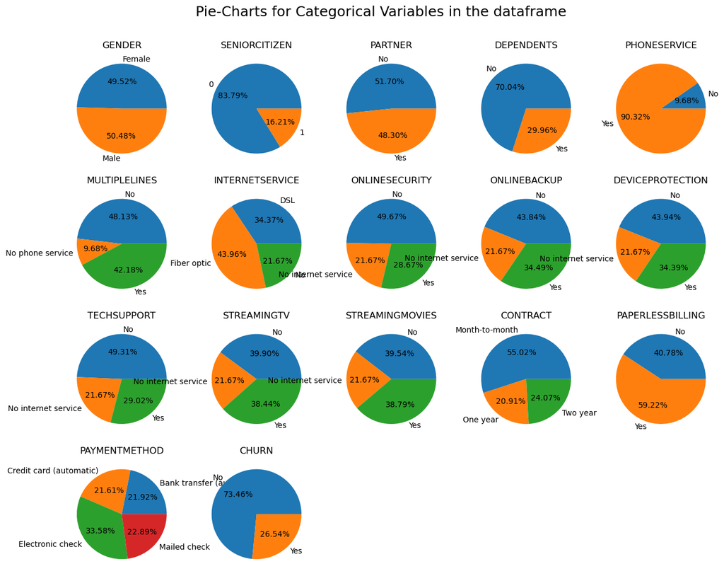

```python
#calling the function to plot pie-charts for categorical variable

pie_charts_for_CategoricalVariable(df_combined_churn, 5)
```

```python
# Renaming the data values of 'PaymentMethod' for better readability

payment_column = {'Electronic check': 'Electronic check', 'Mailed check': 'Mailed check',
                  'Bank transfer (automatic)': 'Bank transfer', 'Credit card (automatic)': 'Credit card'}

df_combined_churn['PaymentMethod'].replace(payment_column, inplace=True)
```

```python
change_col_name = ['gender', 'SeniorCitizen', 'Partner', 'Dependents', 'PhoneService', 'MultipleLines', 'InternetService',
       'OnlineSecurity', 'OnlineBackup', 'DeviceProtection', 'TechSupport', 'StreamingTV', 'StreamingMovies', 'Contract',
        'PaperlessBilling', 'PaymentMethod', 'Churn']

for i in change_col_name:
    df_combined_churn[i] = df_combined_churn[i].astype('object')

df_combined_churn['SeniorCitizen'] = df_combined_churn['SeniorCitizen'].astype('int64')
```

D. Share insights for Q2.c. [2 Marks]

Insights :

- Gender : Gender of the customer

  ```
        Female -> 49.52%
        Male -> 50.48%
  ```

- SeniorCitizen : This feature says whether the customer is a senior citizen (1, 0)

  ```
        Yes -> 16.21%
        No -> 83.79%
  ```

- Partner : This feature says whether the client has a partner (Yes, No) ? Married or not. Living together, being roommates

  ```
        Yes -> 48.30%
        No -> 51.70%
  ```

- Dependents : This feature says whether the client has dependents (Yes, No) (Child, mother, father, grandmother)

  ```
        Yes -> 29.96%
        No -> 70.04%
  ```

- PhoneService : This feature says whether the customer has phone service (Yes, No)

  ```
        Yes -> 90.32%
        No -> 9.68%
  ```

- MultipleLines : This feature says whether the customer has more than one line (Yes, No, No phone service)

  ```
        Yes -> 42.18%
        No -> 48.13%
        No phone service -> 9.68%
  ```

- InternetService : This feature says customer's internet service provider (DSL, Fiber optic, No)

  ```
        DSL -> 34.37%
        Fiber optic -> 43.96%
        No -> 21.67%
  ```

- OnlineSecurity : This feature says whether the customer has online security (Yes, No, No Internet service)

  ```
        Yes -> 28.67%
        No -> 49.67%
        No Internet service -> 21.67%
  ```

- OnlineBackup : This feature says whether the customer has online backup (Yes, No, No Internet service)

- DeviceProtection : This feature says whether the customer has device protection (Yes, No, No Internet service)

  ```
        Yes -> 34.39%
        No -> 43.94%
        No Internet service -> 21.67%
  ```

- TechSupport : This feature says whether the customer receives technical support (Yes, No, No Internet service)

  ```
        Yes -> 29.02%
        No -> 49.31%
        No Internet service -> 21.67%
  ```

- StreamingTV : This feature says whether the customer has streaming TV (Yes, No, no Internet service) (The customer has a third-party indicates whether the provider uses the Internet service to broadcast television programs)

  ```
        Yes -> 38.44%
        No -> 39.90%
        No Internet service -> 21.67%
  ```

- StreamingMovies : This feature says whether the customer has streaming movies (Yes, No, No Internet service) (Customer has a third-party Indicates whether the customer is using the Internet service to stream movies from the provider)

  ```
        Yes -> 38.79%
        No -> 39.54%
        No Internet service -> 21.67%
  ```

- Contract : This feature says duration of the customer's contract (Month to month, One year, Two years)

  ```
        Month to month -> 55.02%
        One year -> 20.91%
        Two years -> 24.07%
  ```

- PaperlessBilling : This feature says whether the customer has a paperless bill (Yes, No)

  ```
        Yes -> 59.22%
        No -> 40.78%
  ```

- PaymentMethod : This feature says customer's payment method (Electronic check, Mailed check, Bank transfer (automatic), Credit card (automatic))

  ```
        Electronic check -> 33.58%
        Mailed check -> 22.89%
        Bank transfer -> 21.92%
        Credit card -> 21.61%
  ```

- Churn : This feature says whether the customer is using or not (Yes or No) - Customers who left in the last month or quarter

  ```
        Yes -> 26.54%
        No -> 73.46%
  ```

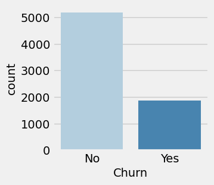

```python
# Apply the Fivethirtyeight style to all plots

plt.style.use('fivethirtyeight')

# Display a frequency distribution for churn

plt.figure(figsize = (3, 3))
ax = sns.countplot(x = df_combined_churn['Churn'], palette="Blues", linewidth = 1)
plt.show()
```

```python
# Create a function to generate boxplots

plots = {1: [111], 2: [121, 122], 3: [131, 132, 133], 4: [221, 222, 223, 224],
         5: [231, 232, 233, 234, 235], 6: [231, 232, 233, 234, 235, 236]}

def boxplot(x, y, df_combined_churn):
    rows = int(str(plots[len(y)][0])[0])
    columns = int(str(plots[len(y)][0])[1])
    plt.figure(figsize=(7*columns, 7*rows))

    for i, j in enumerate(y):
        plt.subplot(plots[len(y)][i])
        ax = sns.boxplot(x=x, y=j, data=df_combined_churn[[x, j]], palette="Blues", linewidth=1)
        ax.set_title(j)

    return plt.show()
```

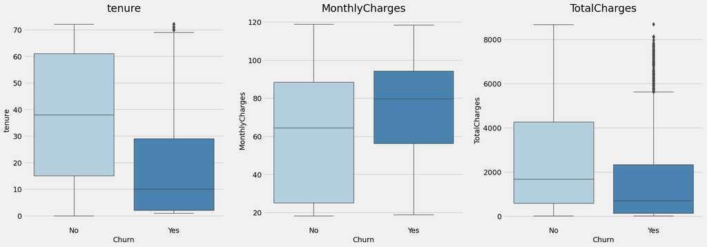

```python
# Generate boxplot for tenure, MonthlyCharges, TotalCharges

boxplot("Churn", ['tenure', 'MonthlyCharges', 'TotalCharges'], df_combined_churn)
```

```python
# Create a function to generate countplots

plots = {1: [111], 2: [121, 122], 3: [131, 132, 133], 4: [221, 222, 223, 224],
         5: [231, 232, 233, 234, 235], 6: [231, 232, 233, 234, 235, 236]}

def countplot(x, y, df_combined_churn):
    rows = int(str(plots[len(y)][0])[0])
    columns = int(str(plots[len(y)][0])[1])
    plt.figure(figsize=(7*columns, 7*rows))

    for i, j in enumerate(y):
        plt.subplot(plots[len(y)][i])
        ax = sns.countplot(x=j, hue=x, data=df_combined_churn, palette="Blues", alpha=0.8, linewidth=0.4, edgecolor='black')
        ax.set_title(j)

    return plt.show()
```

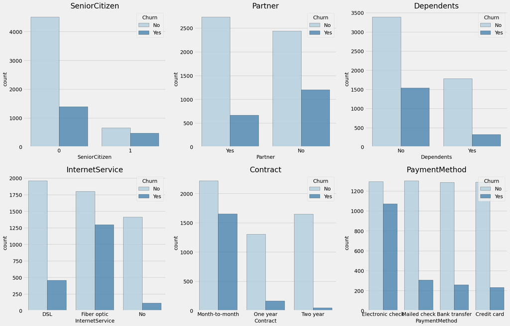

```python
# Generate countplot for SeniorCitizen, Partner, Dependents, InternetService, Contract, PaymentMethod

countplot("Churn", ['SeniorCitizen', 'Partner', 'Dependents', 'InternetService', 'Contract', 'PaymentMethod'], df_combined_churn)
```

```python
# Check for outliers in Numerical features by applying the IQR method checking if values are way outside the IQR borders

numerical_features = ['tenure', 'MonthlyCharges', 'TotalCharges']
df_numerical = df_combined_churn[numerical_features]
df_numerical.describe()

Q1 = df_numerical.quantile(0.25)
Q3 = df_numerical.quantile(0.75)
IQR = Q3 - Q1
IQR
((df_numerical < (Q1 - 1.5 * IQR)) | (df_numerical > (Q3 + 1.5 * IQR))).any()
```

```
tenure            False
MonthlyCharges    False
TotalCharges      False
dtype: bool
```

##### Insight:

No outliers in numerical features detected with the IQR method — no adjustments made.

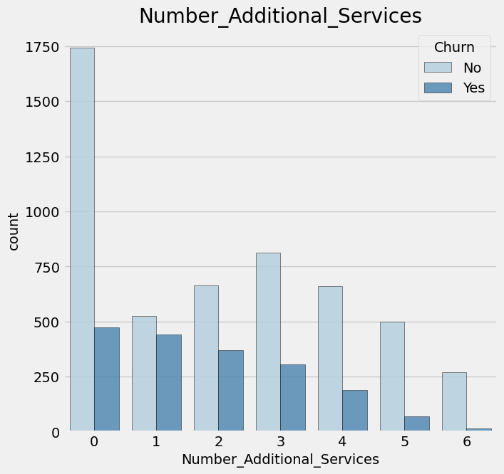

```python
# Generate new feature "Number_Additional_Services" by summing up the number of add-on services consumed

df_combined_churn['Number_Additional_Services'] = (df_combined_churn[['OnlineSecurity', 'DeviceProtection', 'StreamingMovies',
                                                        'TechSupport', 'StreamingTV', 'OnlineBackup']] == 'Yes').sum(axis=1)

# Generate countplot for new feature

countplot("Churn", ['Number_Additional_Services'], df_combined_churn)
```

E. Encode all the appropriate Categorical features with the best suitable approach. [2 Marks]

```python
# Looping through the columns to get unique values per columns

for i in df_combined_churn.columns:
    print(f"Unique {i}'s count: {df_combined_churn[i].nunique()}")
    print(f"{df_combined_churn[i].unique()}\n")
```

```
Unique customerID's count: 7043
['7590-VHVEG' '5575-GNVDE' '3668-QPYBK' ... '4801-JZAZL' '8361-LTMKD'
 '3186-AJIEK']

Unique gender's count: 2
['Female' 'Male']

Unique SeniorCitizen's count: 2
[0 1]

Unique Partner's count: 2
['Yes' 'No']

Unique Dependents's count: 2
['No' 'Yes']

Unique tenure's count: 73
[ 1. 34.  2. 45.  8. 22. 10. 28. 62. 13. 16. 58. 49. 25. 69. 52. 71. 21.
 12. 30. 47. 72. 17. 27.  5. 46. 11. 70. 63. 43. 15. 60. 18. 66.  9.  3.
 31. 50. 64. 56.  7. 42. 35. 48. 29. 65. 38. 68. 32. 55. 37. 36. 41.  6.
  4. 33. 67. 23. 57. 61. 14. 20. 53. 40. 59. 24. 44. 19. 54. 51. 26.  0.
 39.]

Unique PhoneService's count: 2
['No' 'Yes']

Unique MultipleLines's count: 3
['No phone service' 'No' 'Yes']

Unique InternetService's count: 3
['DSL' 'Fiber optic' 'No']

Unique OnlineSecurity's count: 3
['No' 'Yes' 'No internet service']

Unique OnlineBackup's count: 3
['Yes' 'No' 'No internet service']

Unique DeviceProtection's count: 3
['No' 'Yes' 'No internet service']
```

[output cut: 15 more lines]

```

Unique PaymentMethod's count: 4
['Electronic check' 'Mailed check' 'Bank transfer' 'Credit card']

Unique MonthlyCharges's count: 1585
[29.85 56.95 53.85 ... 63.1  44.2  78.7 ]

Unique TotalCharges's count: 6531
[  29.85 1889.5   108.15 ...  346.45  306.6  6844.5 ]

Unique Churn's count: 2
['No' 'Yes']

Unique Number_Additional_Services's count: 7
[1 2 3 0 4 5 6]
```

```python
# Label encoding for identified columns

features_LE = ['Partner', 'Dependents', 'PhoneService', 'PaperlessBilling', 'Churn']

def label_encoding(features, df_combined_churn):
    df_combined_churn['gender'] = df_combined_churn['gender'].map({'Female': 1, 'Male': 0})

    for i in features:
        df_combined_churn[i] = df_combined_churn[i].map({'Yes': 1, 'No': 0})
    return

label_encoding(features_LE, df_combined_churn)
```

```python
# One-Hot-Encoding for identified columns

features_OHE = ['MultipleLines', 'InternetService', 'OnlineSecurity', 'OnlineBackup', 'DeviceProtection', 'TechSupport',
       'StreamingTV', 'StreamingMovies', 'Contract', 'PaymentMethod', 'Number_Additional_Services']

df_combined_churn = pd.get_dummies(df_combined_churn, columns = features_OHE)
```

```python
# Rescaling: Min-Max-Scaling for identified columns

features_MMS = ['tenure', 'MonthlyCharges', 'TotalCharges']

def min_max_scaling(features, df_combined_churn):
    df_features_mms = pd.DataFrame(df_combined_churn, columns = features)
    df_remaining_features = df_combined_churn.drop(columns = features)

    mms = MinMaxScaler()
    rescaled_features = mms.fit_transform(df_features_mms)
    df_rescaled_features = pd.DataFrame(rescaled_features, columns = features, index = df_remaining_features.index)
    df_combined_churn = pd.concat([df_remaining_features, df_rescaled_features], axis = 1)
    return

min_max_scaling(features_MMS, df_combined_churn)
```

```python
# Looping through the columns to get unique values per columns

for i in df_combined_churn.columns:
    print(f"Unique {i}'s count: {df_combined_churn[i].nunique()}")
    print(f"{df_combined_churn[i].unique()}\n")
```

```
Unique customerID's count: 7043
['7590-VHVEG' '5575-GNVDE' '3668-QPYBK' ... '4801-JZAZL' '8361-LTMKD'
 '3186-AJIEK']

Unique gender's count: 2
[1 0]

Unique SeniorCitizen's count: 2
[0 1]

Unique Partner's count: 2
[1 0]

Unique Dependents's count: 2
[0 1]

Unique tenure's count: 73
[ 1. 34.  2. 45.  8. 22. 10. 28. 62. 13. 16. 58. 49. 25. 69. 52. 71. 21.
 12. 30. 47. 72. 17. 27.  5. 46. 11. 70. 63. 43. 15. 60. 18. 66.  9.  3.
 31. 50. 64. 56.  7. 42. 35. 48. 29. 65. 38. 68. 32. 55. 37. 36. 41.  6.
  4. 33. 67. 23. 57. 61. 14. 20. 53. 40. 59. 24. 44. 19. 54. 51. 26.  0.
 39.]

Unique PhoneService's count: 2
[0 1]

Unique PaperlessBilling's count: 2
[1 0]

Unique MonthlyCharges's count: 1585
[29.85 56.95 53.85 ... 63.1  44.2  78.7 ]

Unique TotalCharges's count: 6531
[  29.85 1889.5   108.15 ...  346.45  306.6  6844.5 ]

Unique Churn's count: 2
[0 1]

Unique MultipleLines_No's count: 2
[0 1]
```

[output cut: 96 more lines]

```

Unique Number_Additional_Services_2's count: 2
[0 1]

Unique Number_Additional_Services_3's count: 2
[0 1]

Unique Number_Additional_Services_4's count: 2
[0 1]

Unique Number_Additional_Services_5's count: 2
[0 1]

Unique Number_Additional_Services_6's count: 2
[0 1]
```

[output not shown]

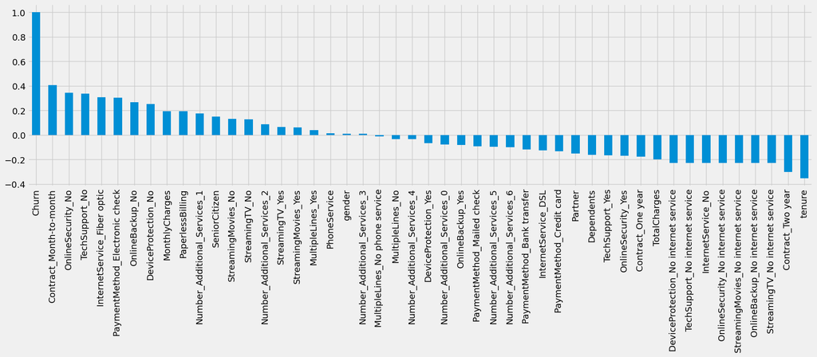

```python
# Show correlation plot for correlation of Churn with each of the remaining features

plt.figure(figsize = (16, 10))
df_combined_churn.corr()['Churn'].sort_values(ascending = False).plot(kind = 'bar', figsize = (20, 5))
```

F. Split the data into 80% train and 20% test. [1 Marks]

```python
# df_combined_churn['customerID'] = df_combined_churn['customerID'].str[:4]
df_combined_churn.drop(['customerID'], axis = 1, inplace = True)

for feature in df_combined_churn.columns: # Loop through all columns in the dataframe
    if df_combined_churn[feature].dtype == 'object': # Only apply for columns with categorical strings
        df_combined_churn[feature] = pd.Categorical(df_combined_churn[feature]) # Replace strings with an integer
```

```python
# Create a separate dataframe consisting only of the features i.e independent attributes

X = df_combined_churn.drop(columns='Churn')
y = df_combined_churn["Churn"]

X.head()
```

|  | gender | SeniorCitizen | Partner | Dependents | tenure | PhoneService | PaperlessBilling | MonthlyCharges | TotalCharges | MultipleLines_No | ... | PaymentMethod_Credit card | PaymentMethod_Electronic check | PaymentMethod_Mailed check | Number_Additional_Services_0 | Number_Additional_Services_1 | Number_Additional_Services_2 | Number_Additional_Services_3 | Number_Additional_Services_4 | Number_Additional_Services_5 | Number_Additional_Services_6 |
| --- | --- | --- | --- | --- | --- | --- | --- | --- | --- | --- | --- | --- | --- | --- | --- | --- | --- | --- | --- | --- | --- |
| 0 | 1 | 0 | 1 | 0 | 1.0 | 0 | 1 | 29.85 | 29.85 | 0 | ... | 0 | 1 | 0 | 0 | 1 | 0 | 0 | 0 | 0 | 0 |
| 1 | 0 | 0 | 0 | 0 | 34.0 | 1 | 0 | 56.95 | 1889.50 | 1 | ... | 0 | 0 | 1 | 0 | 0 | 1 | 0 | 0 | 0 | 0 |
| 2 | 0 | 0 | 0 | 0 | 2.0 | 1 | 1 | 53.85 | 108.15 | 1 | ... | 0 | 0 | 1 | 0 | 0 | 1 | 0 | 0 | 0 | 0 |
| 3 | 0 | 0 | 0 | 0 | 45.0 | 0 | 0 | 42.30 | 1840.75 | 0 | ... | 0 | 0 | 0 | 0 | 0 | 0 | 1 | 0 | 0 | 0 |
| 4 | 1 | 0 | 0 | 0 | 2.0 | 1 | 1 | 70.70 | 151.65 | 1 | ... | 0 | 1 | 0 | 1 | 0 | 0 | 0 | 0 | 0 | 0 |

5 rows × 47 columns

```python
# Split X and y into training and test set in 80:20 ratio

X_train, X_test, y_train, y_test = train_test_split(X, y, test_size = 0.20, random_state = 1, stratify = y)
```

```python
print("{0:0.2f}% data is in training set".format((len(X_train) / len(df_combined_churn.index)) * 100))
print("{0:0.2f}% data is in test set".format((len(X_test) / len(df_combined_churn.index)) * 100))
```

```
79.99% data is in training set
20.01% data is in test set
```

G. Normalize/Standardize the data with the best suitable approach. [2 Marks]

```python
# Standardization (Standard Scalar):
features_SS = ['tenure', 'MonthlyCharges', 'TotalCharges']

def standard_scalar(features, df_combined_churn):
    scaler = StandardScaler()
    df_features_ss = pd.DataFrame(df_combined_churn, columns = features)
    data_scaled = scaler.fit_transform(df_features_ss)

    # Check the mean, standard deviation, Min and Max values
    print('Mean values (tenure, MonthlyCharges and TotalCharges): ', data_scaled.mean(axis = 0))
    print('Standard Deviation values (tenure, MonthlyCharges and TotalCharges): ', data_scaled.std(axis = 0))

    print('Min values (tenure, MonthlyCharges and TotalCharges): ', data_scaled.min(axis = 0))
    print('Max values (tenure, MonthlyCharges and TotalCharges): ', data_scaled.max(axis = 0))

standard_scalar(features_SS, df_combined_churn)
```

```
Mean values (tenure, MonthlyCharges and TotalCharges):  [-2.42127299e-17 -6.40628478e-17 -1.48807402e-17]
Standard Deviation values (tenure, MonthlyCharges and TotalCharges):  [1. 1. 1.]
Min values (tenure, MonthlyCharges and TotalCharges):  [-1.31816495 -1.54585982 -0.99912029]
Max values (tenure, MonthlyCharges and TotalCharges):  [1.61370124 1.79435215 2.82674319]
```

Insight :

As expected, the mean of each variable is now around zero and the standard deviation is set to 1.

Thus, all the variable values lie within the same range.

However, the minimum and maximum values vary according to how spread out the variable was, to begin with, and is highly influenced by the presence of outliers.

```python
# Normalization (Min-Max Scalar):
features_MMS = ['tenure', 'MonthlyCharges', 'TotalCharges']

def min_max_scalar(features, df_combined_churn):
    scaler = MinMaxScaler()
    df_features_mms = pd.DataFrame(df_combined_churn, columns = features)
    data_scaled = scaler.fit_transform(df_features_mms)

    # Check the mean, standard deviation, Min and Max values
    print('Mean values (tenure, MonthlyCharges and TotalCharges): ', data_scaled.mean(axis = 0))
    print('Standard Deviation values (tenure, MonthlyCharges and TotalCharges): ', data_scaled.std(axis = 0))

    print('Min values (tenure, MonthlyCharges and TotalCharges): ', data_scaled.min(axis = 0))
    print('Max values (tenure, MonthlyCharges and TotalCharges): ', data_scaled.max(axis = 0))

min_max_scalar(features_MMS, df_combined_churn)
```

```
Mean values (tenure, MonthlyCharges and TotalCharges):  [0.44959929 0.46280291 0.26114896]
Standard Deviation values (tenure, MonthlyCharges and TotalCharges):  [0.34107969 0.2993822  0.2613789 ]
Min values (tenure, MonthlyCharges and TotalCharges):  [0. 0. 0.]
Max values (tenure, MonthlyCharges and TotalCharges):  [1. 1. 1.]
```

Insight :

After MinMaxScaling, the distributions are not centered at zero and the standard deviation is not 1.

But the minimum and maximum values are standardized across variables, different from what occurs with standardization.

```python
# Robust Scalar (Scaling to median and quantiles):
features_RS = ['tenure', 'MonthlyCharges', 'TotalCharges']

def robust_scalar(features, df_combined_churn):
    scaler = RobustScaler()
    df_features_rs = pd.DataFrame(df_combined_churn, columns = features)
    data_scaled = scaler.fit_transform(df_features_rs)

    # Check the mean, standard deviation, Min and Max values
    print('Mean values (tenure, MonthlyCharges and TotalCharges): ', data_scaled.mean(axis = 0))
    print('Standard Deviation values (tenure, MonthlyCharges and TotalCharges): ', data_scaled.std(axis = 0))

    print('Min values (tenure, MonthlyCharges and TotalCharges): ', data_scaled.min(axis = 0))
    print('Max values (tenure, MonthlyCharges and TotalCharges): ', data_scaled.max(axis = 0))

robust_scalar(features_RS, df_combined_churn)
```

```
Mean values (tenure, MonthlyCharges and TotalCharges):  [ 0.07328584 -0.10282075  0.26133095]
Standard Deviation values (tenure, MonthlyCharges and TotalCharges):  [0.53386386 0.55359542 0.66928445]
Min values (tenure, MonthlyCharges and TotalCharges):  [-0.63043478 -0.95860166 -0.40736473]
Max values (tenure, MonthlyCharges and TotalCharges):  [0.93478261 0.89052438 2.15322622]
```

Insight :

As you can see, the distributions are not centered in zero and the standard deviation is not 1.

Neither are the minimum and maximum values set to a certain upper and lower boundaries like in the MinMaxScaler.

1. Model building and performance improvement : [40 Marks]

A. Train a model using Decision tree and check the performance of the model on train and test data ( 4 marks )

```python
# Build Decision Tree Model
# We will build our model using the DecisionTreeClassifier function. Using default 'gini' criteria to split. Other option include 'entropy'.

decisionTreeClassifier = DecisionTreeClassifier(criterion = 'gini', random_state = 1)
decisionTreeClassifier.fit(X_train, y_train)
```

```
DecisionTreeClassifier(random_state=1)
```

```python
# Predicting labels on the test set

y_pred_train = decisionTreeClassifier.predict(X_train)
y_pred_test = decisionTreeClassifier.predict(X_test)

print(decisionTreeClassifier.score(X_train, y_train))
print(decisionTreeClassifier.score(X_test, y_test))
print()
print(metrics.recall_score(y_train, y_pred_train))
print(metrics.recall_score(y_test, y_pred_test))
print()
print(metrics.precision_score(y_train, y_pred_train))
print(metrics.precision_score(y_test, y_pred_test))
print()
print('Accuracy Score on train data: ', accuracy_score(y_true = y_train, y_pred = y_pred_train))
print('Accuracy Score on test data: ', accuracy_score(y_true = y_test, y_pred = y_pred_test))
```

```
0.9978700745473909
0.7388218594748048

0.9919732441471572
0.5187165775401069

1.0
0.5078534031413613

Accuracy Score on train data:  0.9978700745473909
Accuracy Score on test data:  0.7388218594748048
```

```python
# Visualizing the Decision Tree using graphviz

train_char_label = ['No', 'Yes']
Decision_Tree_Churn_File = open('Decision_Tree_Churn.dot', 'w')
dot_data = export_graphviz(decisionTreeClassifier, out_file = Decision_Tree_Churn_File, feature_names = list(X_train), class_names = list(train_char_label))
Decision_Tree_Churn_File.close()
```

```python
# Works only if "dot" command works on you machine

retCode = system("dot -Tpng Decision_Tree_Churn.dot -o DecisionTree.png")

if(retCode > 0):
    print("system command returning error: " + str(retCode))
else:
    display(Image("DecisionTree.png"))
```

```
system command returning error: 1
```

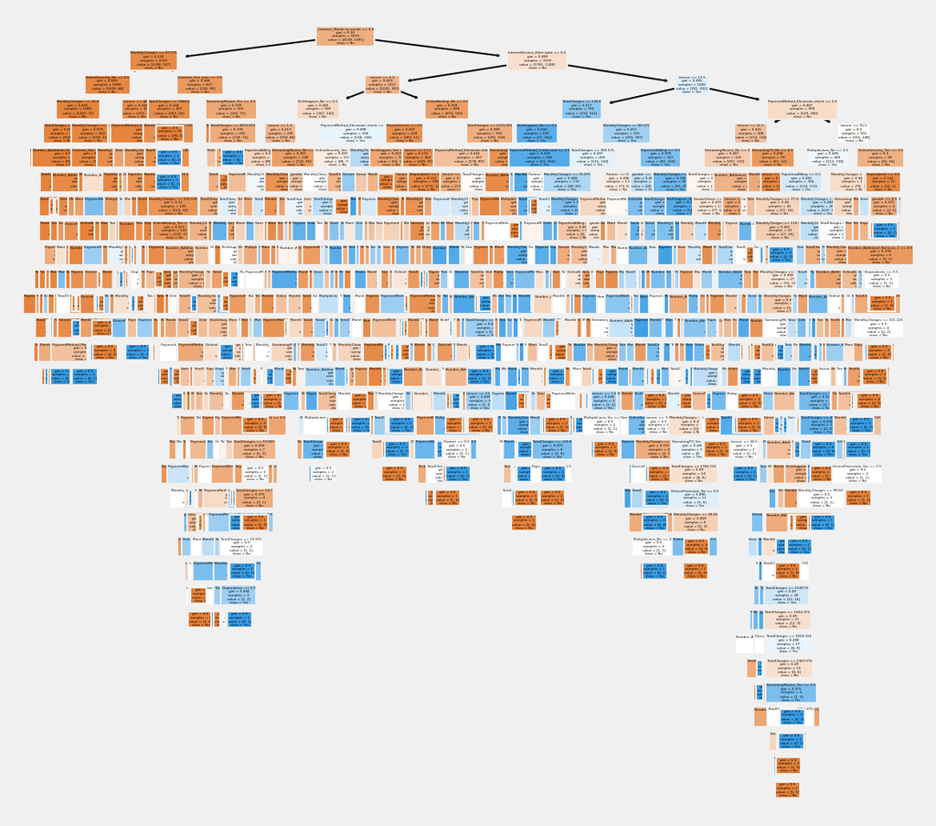

```python
# If graphviz doesn't work, we can use plot_tree method from sklearn.tree

fn = list(X_train)
cn = ['No', 'Yes']
fig, axes = plt.subplots(nrows = 1, ncols = 1, figsize = (4, 4), dpi = 300)
plot_tree(decisionTreeClassifier, feature_names = fn, class_names = cn, filled = True)

fig.savefig('DecisionTree.png')
```

```python
# importance of features in the tree building ( The importance of a feature is computed as the
# (normalized) total reduction of the criterion brought by that feature. It is also known as the Gini importance )

print(pd.DataFrame(decisionTreeClassifier.feature_importances_, columns = ["Imp"], index = X_train.columns))
```

```
                                           Imp
gender                                0.026702
SeniorCitizen                         0.017353
Partner                               0.023554
Dependents                            0.016277
tenure                                0.110229
PhoneService                          0.001132
PaperlessBilling                      0.019599
MonthlyCharges                        0.186298
TotalCharges                          0.180983
MultipleLines_No                      0.007069
MultipleLines_No phone service        0.004418
MultipleLines_Yes                     0.004251
InternetService_DSL                   0.000000
InternetService_Fiber optic           0.051509
InternetService_No                    0.000000
OnlineSecurity_No                     0.006214
OnlineSecurity_No internet service    0.000000
OnlineSecurity_Yes                    0.008651
OnlineBackup_No                       0.009886
OnlineBackup_No internet service      0.000000
OnlineBackup_Yes                      0.006663
DeviceProtection_No                   0.005511
DeviceProtection_No internet service  0.000000
DeviceProtection_Yes                  0.009919
TechSupport_No                        0.015104
TechSupport_No internet service       0.000000
TechSupport_Yes                       0.007801
StreamingTV_No                        0.004977
StreamingTV_No internet service       0.000000
StreamingTV_Yes                       0.004433
StreamingMovies_No                    0.011376
StreamingMovies_No internet service   0.000687
StreamingMovies_Yes                   0.005326
Contract_Month-to-month               0.166300
Contract_One year                     0.003501
Contract_Two year                     0.000270
PaymentMethod_Bank transfer           0.013721
PaymentMethod_Credit card             0.008836
PaymentMethod_Electronic check        0.023263
PaymentMethod_Mailed check            0.010802
Number_Additional_Services_0          0.004048
Number_Additional_Services_1          0.008225
Number_Additional_Services_2          0.005222
Number_Additional_Services_3          0.005242
Number_Additional_Services_4          0.002414
Number_Additional_Services_5          0.001265
Number_Additional_Services_6          0.000970
```

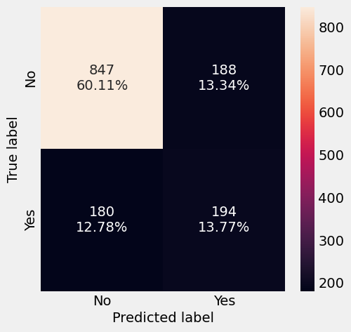

```python
cm = confusion_matrix(y_test, y_pred_test, labels = [0, 1])
df_cm = pd.DataFrame(cm, index = [i for i in ["No", "Yes"]], columns = [i for i in ["No", "Yes"]])

group_counts = ["{0:0.0f}".format(value) for value in cm.flatten()]
group_percentages = ["{0:.2%}".format(value) for value in cm.flatten()/np.sum(cm)]

labels = [f"{v1}\n{v2}" for v1, v2 in zip(group_counts, group_percentages)]
labels = np.asarray(labels).reshape(2, 2)

plt.figure(figsize = (5, 5))
sns.heatmap(df_cm, annot = labels, fmt = '')

plt.ylabel("True label")
plt.xlabel("Predicted label")
```

```python
# Reducing over fitting (Regularization)

decisionTreeClassifierR = DecisionTreeClassifier(criterion = 'gini', max_depth = 5, random_state=1)
decisionTreeClassifierR.fit(X_train, y_train)
```

```
DecisionTreeClassifier(max_depth=5, random_state=1)
```

```python
# Predicting labels on the test set

y_pred_train = decisionTreeClassifierR.predict(X_train)
y_pred_test = decisionTreeClassifierR.predict(X_test)

print(decisionTreeClassifierR.score(X_train, y_train))
print(decisionTreeClassifierR.score(X_test, y_test))
print()
print(metrics.recall_score(y_train, y_pred_train))
print(metrics.recall_score(y_test, y_pred_test))
print()
print(metrics.precision_score(y_train, y_pred_train))
print(metrics.precision_score(y_test, y_pred_test))
print()
print('Accuracy Score on train data: ', accuracy_score(y_true = y_train, y_pred = y_pred_train))
print('Accuracy Score on test data: ', accuracy_score(y_true = y_test, y_pred = y_pred_test))
```

```
0.8008519701810437
0.7913413768630234

0.5792642140468227
0.5561497326203209

0.637233259749816
0.6190476190476191

Accuracy Score on train data:  0.8008519701810437
Accuracy Score on test data:  0.7913413768630234
```

```python
# Visualizing the Decision Tree using graphviz

train_char_label = ['No', 'Yes']
Decision_Tree_Churn_FileR = open('Decision_Tree_ChurnR.dot', 'w')
dot_data = export_graphviz(decisionTreeClassifierR, out_file = Decision_Tree_Churn_FileR, feature_names = list(X_train), class_names = list(train_char_label))
Decision_Tree_Churn_FileR.close()
```

```python
# Works only if "dot" command works on you machine

retCode = system("dot -Tpng Decision_Tree_ChurnR.dot -o DecisionTreeR.png")

if(retCode > 0):
    print("system command returning error: " + str(retCode))
else:
    display(Image("DecisionTreeR.png"))
```

```
system command returning error: 1
```

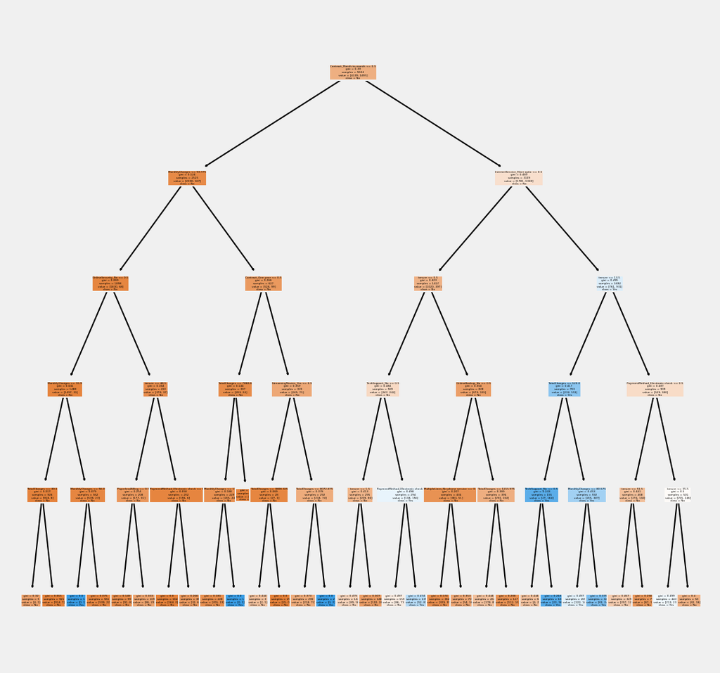

```python
# If graphviz doesn't work, we can use plot_tree method from sklearn.tree

fn = list(X_train)
cn = ['No', 'Yes']
fig, axes = plt.subplots(nrows = 1, ncols = 1, figsize = (4, 4), dpi = 300)
plot_tree(decisionTreeClassifierR, feature_names = fn, class_names = cn, filled = True)

fig.savefig('DecisionTreeR.png')
```

```python
# importance of features in the tree building ( The importance of a feature is computed as the
# (normalized) total reduction of the criterion brought by that feature. It is also known as the Gini importance )

print(pd.DataFrame(decisionTreeClassifierR.feature_importances_, columns = ["Imp"], index = X_train.columns))
```

```
                                           Imp
gender                                0.000000
SeniorCitizen                         0.000000
Partner                               0.000000
Dependents                            0.000000
tenure                                0.173161
PhoneService                          0.000000
PaperlessBilling                      0.002448
MonthlyCharges                        0.042755
TotalCharges                          0.034223
MultipleLines_No                      0.000000
MultipleLines_No phone service        0.002866
MultipleLines_Yes                     0.000000
InternetService_DSL                   0.000000
InternetService_Fiber optic           0.156576
InternetService_No                    0.000000
OnlineSecurity_No                     0.004311
OnlineSecurity_No internet service    0.000000
OnlineSecurity_Yes                    0.000000
OnlineBackup_No                       0.012330
OnlineBackup_No internet service      0.000000
OnlineBackup_Yes                      0.000000
DeviceProtection_No                   0.000000
DeviceProtection_No internet service  0.000000
DeviceProtection_Yes                  0.000000
TechSupport_No                        0.028190
TechSupport_No internet service       0.000000
TechSupport_Yes                       0.000000
StreamingTV_No                        0.000000
StreamingTV_No internet service       0.000000
StreamingTV_Yes                       0.000000
StreamingMovies_No                    0.000000
StreamingMovies_No internet service   0.000000
StreamingMovies_Yes                   0.003371
Contract_Month-to-month               0.505512
Contract_One year                     0.010642
Contract_Two year                     0.000000
PaymentMethod_Bank transfer           0.000000
PaymentMethod_Credit card             0.000000
PaymentMethod_Electronic check        0.023616
PaymentMethod_Mailed check            0.000000
Number_Additional_Services_0          0.000000
Number_Additional_Services_1          0.000000
Number_Additional_Services_2          0.000000
Number_Additional_Services_3          0.000000
Number_Additional_Services_4          0.000000
Number_Additional_Services_5          0.000000
Number_Additional_Services_6          0.000000
```

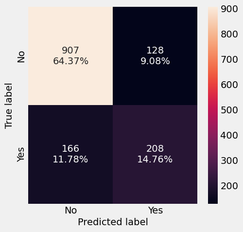

```python
cm = confusion_matrix(y_test, y_pred_test, labels = [0, 1])
df_cm = pd.DataFrame(cm, index = [i for i in ["No", "Yes"]], columns = [i for i in ["No", "Yes"]])

group_counts = ["{0:0.0f}".format(value) for value in cm.flatten()]
group_percentages = ["{0:.2%}".format(value) for value in cm.flatten()/np.sum(cm)]

labels = [f"{v1}\n{v2}" for v1, v2 in zip(group_counts, group_percentages)]
labels = np.asarray(labels).reshape(2, 2)

plt.figure(figsize = (5, 5))
sns.heatmap(df_cm, annot = labels, fmt = '')

plt.ylabel("True label")
plt.xlabel("Predicted label")
```

B. Use grid search and improve the performance of the Decision tree model, check the performance of the model on train and test data , provide the differences observed in performance in Q3.a and Q3.b ( 5 marks )

```python
# Build Decision tree Model

decisionTreeClassifier_tuned = DecisionTreeClassifier(random_state = 1)

parameters = {
    'criterion': ['gini', 'entropy'],
    'max_depth': np.arange(1, 10),
    'max_features': np.arange(1, 10)
}

acc_scorer = metrics.make_scorer(metrics.recall_score)

# Run the grid search
model_DTC = GridSearchCV(decisionTreeClassifier_tuned, parameters, scoring = acc_scorer, cv = 3, n_jobs = -1)
model_DTC = model_DTC.fit(X_train, y_train)

# Set the best of combination of parameters
decisionTreeClassifier_tuned = model_DTC.best_estimator_

# Fit the best algorithm to the data
decisionTreeClassifier_tuned.fit(X_train, y_train)

print('Best estimator are: ' + str(model_DTC.best_estimator_))
print('Best hyperparameters are: ' + str(model_DTC.best_params_))
print('Best score is: ' + str(model_DTC.best_score_))
```

```
Best estimator are: DecisionTreeClassifier(criterion='entropy', max_depth=6, max_features=7,
                       random_state=1)
Best hyperparameters are: {'criterion': 'entropy', 'max_depth': 6, 'max_features': 7}
Best score is: 0.5484516556540121
```

```python
# Predicting labels on the test set

y_pred_train = decisionTreeClassifier_tuned.predict(X_train)
y_pred_test = decisionTreeClassifier_tuned.predict(X_test)

print(decisionTreeClassifier_tuned.score(X_train, y_train))
print(decisionTreeClassifier_tuned.score(X_test, y_test))
print()
print(metrics.recall_score(y_train, y_pred_train))
print(metrics.recall_score(y_test, y_pred_test))
print()
print(metrics.precision_score(y_train, y_pred_train))
print(metrics.precision_score(y_test, y_pred_test))
print()
print('Accuracy Score on train data: ', accuracy_score(y_true = y_train, y_pred = y_pred_train))
print('Accuracy Score on test data: ', accuracy_score(y_true = y_test, y_pred = y_pred_test))
```

```
0.7933972310969116
0.7700496806245565

0.45217391304347826
0.4037433155080214

0.6620959843290891
0.5992063492063492

Accuracy Score on train data:  0.7933972310969116
Accuracy Score on test data:  0.7700496806245565
```

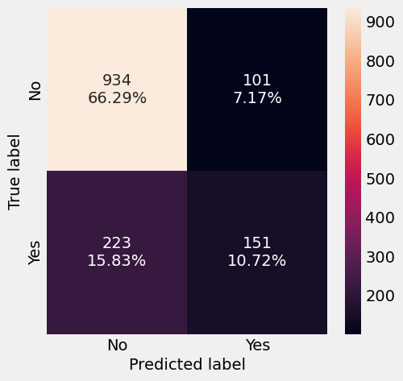

```python
cm = confusion_matrix(y_test, y_pred_test, labels = [0, 1])
df_cm = pd.DataFrame(cm, index = [i for i in ["No", "Yes"]], columns = [i for i in ["No", "Yes"]])

group_counts = ["{0:0.0f}".format(value) for value in cm.flatten()]
group_percentages = ["{0:.2%}".format(value) for value in cm.flatten()/np.sum(cm)]

labels = [f"{v1}\n{v2}" for v1, v2 in zip(group_counts, group_percentages)]
labels = np.asarray(labels).reshape(2, 2)

plt.figure(figsize = (5, 5))
sns.heatmap(df_cm, annot = labels, fmt = '')

plt.ylabel("True label")
plt.xlabel("Predicted label")
```

```python
# Tuned Model

print(metrics.classification_report(y_test, decisionTreeClassifier_tuned.predict(X_test)))
```

```
              precision    recall  f1-score   support

           0       0.81      0.90      0.85      1035
           1       0.60      0.40      0.48       374

    accuracy                           0.77      1409
   macro avg       0.70      0.65      0.67      1409
weighted avg       0.75      0.77      0.75      1409
```

##### Thus, the Accuracy of the Tuned Decision Tree Classifier model came out to be 77%

```python
# Un-Tuned Model

print(metrics.classification_report(y_test, decisionTreeClassifier.predict(X_test)))
```

```
              precision    recall  f1-score   support

           0       0.82      0.82      0.82      1035
           1       0.51      0.52      0.51       374

    accuracy                           0.74      1409
   macro avg       0.67      0.67      0.67      1409
weighted avg       0.74      0.74      0.74      1409
```

##### Thus, the Accuracy of the Un-Tuned Decision Tree Classifier model came out to be 74%

Insight :

- The model accuracy of Tuned decision tree classification model has increased to 77% compared to Un-Tuned decision tree classification model accuracy which is 74%

C. Train a model using Random forest and check the performance of the model on train and test data ( 4 marks )

```python
# Build Random Forest Model

randomForestClassifier = RandomForestClassifier(n_estimators = 50, random_state = 1, max_features = 12)
randomForestClassifier.fit(X_train, y_train)
```

```
RandomForestClassifier(max_features=12, n_estimators=50, random_state=1)
```

```python
# Predicting labels on the test set

y_pred_train = randomForestClassifier.predict(X_train)
y_pred_test = randomForestClassifier.predict(X_test)

print(randomForestClassifier.score(X_train, y_train))
print(randomForestClassifier.score(X_test, y_test))
print()
print(metrics.recall_score(y_train, y_pred_train))
print(metrics.recall_score(y_test, y_pred_test))
print()
print(metrics.precision_score(y_train, y_pred_train))
print(metrics.precision_score(y_test, y_pred_test))
print()
print('Accuracy Score on train data: ', accuracy_score(y_true = y_train, y_pred = y_pred_train))
print('Accuracy Score on test data: ', accuracy_score(y_true = y_test, y_pred = y_pred_test))
```

```
0.9971600993965212
0.7892122072391767

0.9933110367892977
0.4839572192513369

0.9959758551307847
0.6350877192982456

Accuracy Score on train data:  0.9971600993965212
Accuracy Score on test data:  0.7892122072391767
```

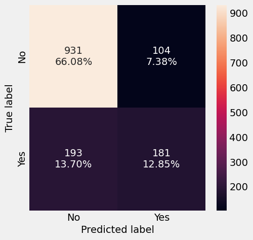

```python
cm = confusion_matrix(y_test, y_pred_test, labels = [0, 1])
df_cm = pd.DataFrame(cm, index = [i for i in ["No", "Yes"]], columns = [i for i in ["No", "Yes"]])

group_counts = ["{0:0.0f}".format(value) for value in cm.flatten()]
group_percentages = ["{0:.2%}".format(value) for value in cm.flatten()/np.sum(cm)]

labels = [f"{v1}\n{v2}" for v1, v2 in zip(group_counts, group_percentages)]
labels = np.asarray(labels).reshape(2, 2)

plt.figure(figsize = (5, 5))
sns.heatmap(df_cm, annot = labels, fmt = '')

plt.ylabel("True label")
plt.xlabel("Predicted label")
```

D. Use grid search and improve the performance of the Random tree model, check the performance of the model on train and test data , provide the differences observed in performance in Q3.c and Q3.d ( 5 marks )

```python
# Build Random Forest Model

randomForestClassifier_tuned = RandomForestClassifier(random_state = 1)

parameters = {
    'class_weight': [{0: 0.3, 1: 0.7}],
    'n_estimators': [2, 3, 4, 5, 6, 7, 8],
    'max_depth': np.arange(1, 10),
    'max_features': np.arange(1, 10)
}

acc_scorer = metrics.make_scorer(metrics.recall_score)

# Run the grid search
model_RFC = GridSearchCV(randomForestClassifier_tuned, parameters, scoring = acc_scorer, cv = 3, n_jobs = -1)
model_RFC = model_RFC.fit(X_train, y_train)

# Set the best of combination of parameters
randomForestClassifier_tuned = model_RFC.best_estimator_

# Fit the best algorithm to the data
randomForestClassifier_tuned.fit(X_train, y_train)

print('Best estimator are: ' + str(model_RFC.best_estimator_))
print('Best hyperparameters are: ' + str(model_RFC.best_params_))
print('Best score is: ' + str(model_RFC.best_score_))
```

```
Best estimator are: RandomForestClassifier(class_weight={0: 0.3, 1: 0.7}, max_depth=2,
                       max_features=7, n_estimators=3, random_state=1)
Best hyperparameters are: {'class_weight': {0: 0.3, 1: 0.7}, 'max_depth': 2, 'max_features': 7, 'n_estimators': 3}
Best score is: 0.8314245626460418
```

```python
# Predicting labels on the test set

y_pred_train = randomForestClassifier_tuned.predict(X_train)
y_pred_test = randomForestClassifier_tuned.predict(X_test)

print(randomForestClassifier_tuned.score(X_train, y_train))
print(randomForestClassifier_tuned.score(X_test, y_test))
print()
print(metrics.recall_score(y_train, y_pred_train))
print(metrics.recall_score(y_test, y_pred_test))
print()
print(metrics.precision_score(y_train, y_pred_train))
print(metrics.precision_score(y_test, y_pred_test))
print()
print('Accuracy Score on train data: ', accuracy_score(y_true = y_train, y_pred = y_pred_train))
print('Accuracy Score on test data: ', accuracy_score(y_true = y_test, y_pred = y_pred_test))
```

```
0.6980830670926518
0.6933995741660752

0.8060200668896321
0.8101604278074866

0.46062691131498473
0.4563253012048193

Accuracy Score on train data:  0.6980830670926518
Accuracy Score on test data:  0.6933995741660752
```

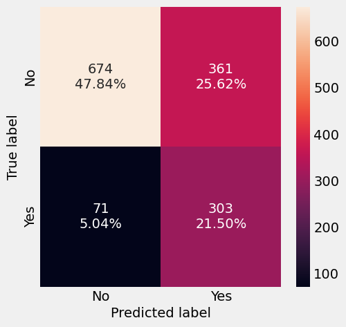

```python
cm = confusion_matrix(y_test, y_pred_test, labels = [0, 1])
df_cm = pd.DataFrame(cm, index = [i for i in ["No", "Yes"]], columns = [i for i in ["No", "Yes"]])

group_counts = ["{0:0.0f}".format(value) for value in cm.flatten()]
group_percentages = ["{0:.2%}".format(value) for value in cm.flatten()/np.sum(cm)]

labels = [f"{v1}\n{v2}" for v1, v2 in zip(group_counts, group_percentages)]
labels = np.asarray(labels).reshape(2, 2)

plt.figure(figsize = (5, 5))
sns.heatmap(df_cm, annot = labels, fmt = '')

plt.ylabel("True label")
plt.xlabel("Predicted label")
```

```python
# Tuned Model

print(metrics.classification_report(y_test, randomForestClassifier_tuned.predict(X_test)))
```

```
              precision    recall  f1-score   support

           0       0.90      0.65      0.76      1035
           1       0.46      0.81      0.58       374

    accuracy                           0.69      1409
   macro avg       0.68      0.73      0.67      1409
weighted avg       0.79      0.69      0.71      1409
```

##### Thus, the Accuracy of the Tuned Random Forest Classifier model came out to be 69%

```python
# Un-Tuned Model

print(metrics.classification_report(y_test, randomForestClassifier.predict(X_test)))
```

```
              precision    recall  f1-score   support

           0       0.83      0.90      0.86      1035
           1       0.64      0.48      0.55       374

    accuracy                           0.79      1409
   macro avg       0.73      0.69      0.71      1409
weighted avg       0.78      0.79      0.78      1409
```

##### Thus, the Accuracy of the Un-Tuned Random Forest Classifier model came out to be 79%

Insight :

- The model accuracy of Tuned random forest classification model has decreased to 69% compared to Un-Tuned random forest classification model accuracy which is 79%

E. Train a model using Adaboost and check the performance of the model on train and test data ( 4 marks )

```python
# Build AdaBoost Model

adaBoostClassifier = AdaBoostClassifier(n_estimators = 50, random_state = 1)
adaBoostClassifier.fit(X_train, y_train)
```

```
AdaBoostClassifier(random_state=1)
```

```python
# Predicting labels on the test set

y_pred_train = adaBoostClassifier.predict(X_train)
y_pred_test = adaBoostClassifier.predict(X_test)

print(adaBoostClassifier.score(X_train, y_train))
print(adaBoostClassifier.score(X_test, y_test))
print()
print(metrics.recall_score(y_train, y_pred_train))
print(metrics.recall_score(y_test, y_pred_test))
print()
print(metrics.precision_score(y_train, y_pred_train))
print(metrics.precision_score(y_test, y_pred_test))
print()
print('Accuracy Score on train data: ', accuracy_score(y_true = y_train, y_pred = y_pred_train))
print('Accuracy Score on test data: ', accuracy_score(y_true = y_test, y_pred = y_pred_test))
```

```
0.8099041533546326
0.7955997161107168

0.5545150501672241
0.5320855614973262

0.6717990275526742
0.6378205128205128

Accuracy Score on train data:  0.8099041533546326
Accuracy Score on test data:  0.7955997161107168
```

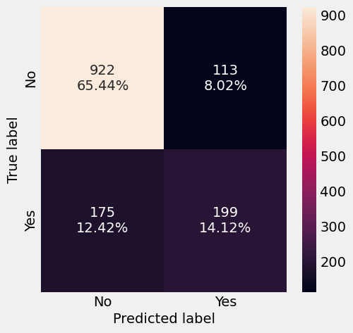

```python
cm = confusion_matrix(y_test, y_pred_test, labels = [0, 1])
df_cm = pd.DataFrame(cm, index = [i for i in ["No", "Yes"]], columns = [i for i in ["No", "Yes"]])

group_counts = ["{0:0.0f}".format(value) for value in cm.flatten()]
group_percentages = ["{0:.2%}".format(value) for value in cm.flatten()/np.sum(cm)]

labels = [f"{v1}\n{v2}" for v1, v2 in zip(group_counts, group_percentages)]
labels = np.asarray(labels).reshape(2, 2)

plt.figure(figsize = (5, 5))
sns.heatmap(df_cm, annot = labels, fmt = '')

plt.ylabel("True label")
plt.xlabel("Predicted label")
```

F. Use grid search and improve the performance of the Adaboost model, check the performance of the model on train and test data , provide the differences observed in performance in Q3.e and Q3.f ( 5 marks )

```python
# Build Ada Boost Model

adaBoostClassifier_tuned = AdaBoostClassifier(random_state = 1)

parameters = {
    'n_estimators': [2, 3, 4, 5, 6, 7, 8],
    'learning_rate': [(0.97 + x / 100) for x in range(0, 8)],
    'algorithm': ['SAMME', 'SAMME.R']
}

acc_scorer = metrics.make_scorer(metrics.recall_score)

# Run the grid search
model_ABC = GridSearchCV(adaBoostClassifier_tuned, parameters, scoring = acc_scorer, cv = 3, n_jobs = -1)
model_ABC = model_ABC.fit(X_train, y_train)

# Set the best of combination of parameters
adaBoostClassifier_tuned = model_ABC.best_estimator_

# Fit the best algorithm to the data
adaBoostClassifier_tuned.fit(X_train, y_train)

print('Best estimator are: ' + str(model_ABC.best_estimator_))
print('Best hyperparameters are: ' + str(model_ABC.best_params_))
print('Best score is: ' + str(model_ABC.best_score_))
```

```
Best estimator are: AdaBoostClassifier(learning_rate=1.02, n_estimators=3, random_state=1)
Best hyperparameters are: {'algorithm': 'SAMME.R', 'learning_rate': 1.02, 'n_estimators': 3}
Best score is: 0.654150335476844
```

```python
# Predicting labels on the test set

y_pred_train = adaBoostClassifier_tuned.predict(X_train)
y_pred_test = adaBoostClassifier_tuned.predict(X_test)

print(adaBoostClassifier_tuned.score(X_train, y_train))
print(adaBoostClassifier_tuned.score(X_test, y_test))
print()
print(metrics.recall_score(y_train, y_pred_train))
print(metrics.recall_score(y_test, y_pred_test))
print()
print(metrics.precision_score(y_train, y_pred_train))
print(metrics.precision_score(y_test, y_pred_test))
print()
print('Accuracy Score on train data: ', accuracy_score(y_true = y_train, y_pred = y_pred_train))
print('Accuracy Score on test data: ', accuracy_score(y_true = y_test, y_pred = y_pred_test))
```

```
0.7648207312744054
0.7530163236337828

0.622742474916388
0.6176470588235294

0.5502364066193853
0.5298165137614679

Accuracy Score on train data:  0.7648207312744054
Accuracy Score on test data:  0.7530163236337828
```

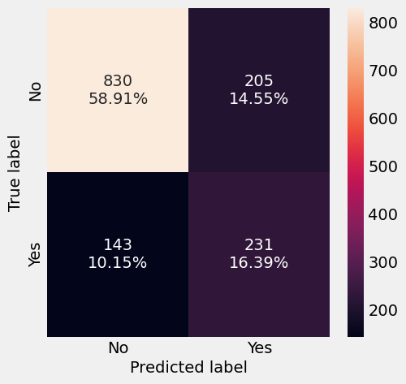

```python
cm = confusion_matrix(y_test, y_pred_test, labels = [0, 1])
df_cm = pd.DataFrame(cm, index = [i for i in ["No", "Yes"]], columns = [i for i in ["No", "Yes"]])

group_counts = ["{0:0.0f}".format(value) for value in cm.flatten()]
group_percentages = ["{0:.2%}".format(value) for value in cm.flatten()/np.sum(cm)]

labels = [f"{v1}\n{v2}" for v1, v2 in zip(group_counts, group_percentages)]
labels = np.asarray(labels).reshape(2, 2)

plt.figure(figsize = (5, 5))
sns.heatmap(df_cm, annot = labels, fmt = '')

plt.ylabel("True label")
plt.xlabel("Predicted label")
```

```python
# Tuned Model

print(metrics.classification_report(y_test, adaBoostClassifier_tuned.predict(X_test)))
```

```
              precision    recall  f1-score   support

           0       0.85      0.80      0.83      1035
           1       0.53      0.62      0.57       374

    accuracy                           0.75      1409
   macro avg       0.69      0.71      0.70      1409
weighted avg       0.77      0.75      0.76      1409
```

##### Thus, the Accuracy of the Tuned Ada Boost Classifier model came out to be 75%

```python
# Un-Tuned Model

print(metrics.classification_report(y_test, adaBoostClassifier.predict(X_test)))
```

```
              precision    recall  f1-score   support

           0       0.84      0.89      0.86      1035
           1       0.64      0.53      0.58       374

    accuracy                           0.80      1409
   macro avg       0.74      0.71      0.72      1409
weighted avg       0.79      0.80      0.79      1409
```

##### Thus, the Accuracy of the Un-Tuned Ada Boost Classifier model came out to be 80%

Insight :

- The model accuracy of Tuned adaboost classification model has descreaed to 75% compared to Un-Tuned adaboost classification model accuracy which is 80%

G. Train a model using GradientBoost and check the performance of the model on train and test data ( 4 marks )

```python
# Build Gradient Boost Model

gradientBoostingClassifier = GradientBoostingClassifier(n_estimators = 50, random_state = 1)
gradientBoostingClassifier.fit(X_train, y_train)
```

```
GradientBoostingClassifier(n_estimators=50, random_state=1)
```

```python
# Predicting labels on the test set

y_pred_train = gradientBoostingClassifier.predict(X_train)
y_pred_test = gradientBoostingClassifier.predict(X_test)

print(gradientBoostingClassifier.score(X_train, y_train))
print(gradientBoostingClassifier.score(X_test, y_test))
print()
print(metrics.recall_score(y_train, y_pred_train))
print(metrics.recall_score(y_test, y_pred_test))
print()
print(metrics.precision_score(y_train, y_pred_train))
print(metrics.precision_score(y_test, y_pred_test))
print()
print('Accuracy Score on train data: ', accuracy_score(y_true = y_train, y_pred = y_pred_train))
print('Accuracy Score on test data: ', accuracy_score(y_true = y_test, y_pred = y_pred_test))
```

```
0.8177138800141995
0.8069552874378992

0.5464882943143813
0.4946524064171123

0.7006861063464837
0.6902985074626866

Accuracy Score on train data:  0.8177138800141995
Accuracy Score on test data:  0.8069552874378992
```

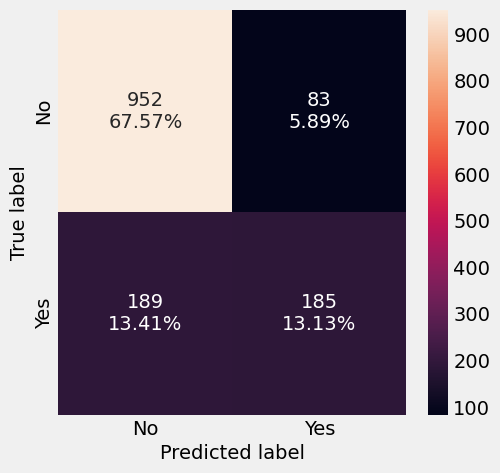

```python
cm = confusion_matrix(y_test, y_pred_test, labels = [0, 1])
df_cm = pd.DataFrame(cm, index = [i for i in ["No", "Yes"]], columns = [i for i in ["No", "Yes"]])

group_counts = ["{0:0.0f}".format(value) for value in cm.flatten()]
group_percentages = ["{0:.2%}".format(value) for value in cm.flatten()/np.sum(cm)]

labels = [f"{v1}\n{v2}" for v1, v2 in zip(group_counts, group_percentages)]
labels = np.asarray(labels).reshape(2, 2)

plt.figure(figsize = (5, 5))
sns.heatmap(df_cm, annot = labels, fmt = '')

plt.ylabel("True label")
plt.xlabel("Predicted label")
```

H. Use grid search and improve the performance of the GradientBoost model, check the performance of the model on train and test data , provide the differences observed in performance in Q3.g and Q3.h ( 5 marks )

```python
# Build Gradient Boost Model

gradientBoostingClassifier_tuned = GradientBoostingClassifier(random_state = 1)

parameters = {
    'n_estimators': [2, 3, 4, 5, 6, 7, 8],
    'learning_rate': [(0.97 + x / 100) for x in range(0, 8)],
    'max_depth': np.arange(1, 10),
    'max_features': np.arange(1, 10)
}

acc_scorer = metrics.make_scorer(metrics.recall_score)

# Run the grid search
model_GBC = GridSearchCV(gradientBoostingClassifier_tuned, parameters, scoring = acc_scorer, cv = 3, n_jobs = -1)
model_GBC = model_GBC.fit(X_train, y_train)

# Set the best of combination of parameters
gradientBoostingClassifier_tuned = model_GBC.best_estimator_

# Fit the best algorithm to the data
gradientBoostingClassifier_tuned.fit(X_train, y_train)

print('Best estimator are: ' + str(model_GBC.best_estimator_))
print('Best hyperparameters are: ' + str(model_GBC.best_params_))
print('Best score is: ' + str(model_GBC.best_score_))
```

```
Best estimator are: GradientBoostingClassifier(learning_rate=1.03, max_depth=2, max_features=8,
                           n_estimators=2, random_state=1)
Best hyperparameters are: {'learning_rate': 1.03, 'max_depth': 2, 'max_features': 8, 'n_estimators': 2}
Best score is: 0.5853219155848511
```

```python
# Predicting labels on the test set

y_pred_train = gradientBoostingClassifier_tuned.predict(X_train)
y_pred_test = gradientBoostingClassifier_tuned.predict(X_test)

print(gradientBoostingClassifier_tuned.score(X_train, y_train))
print(gradientBoostingClassifier_tuned.score(X_test, y_test))
print()
print(metrics.recall_score(y_train, y_pred_train))
print(metrics.recall_score(y_test, y_pred_test))
print()
print(metrics.precision_score(y_train, y_pred_train))
print(metrics.precision_score(y_test, y_pred_test))
print()
print('Accuracy Score on train data: ', accuracy_score(y_true = y_train, y_pred = y_pred_train))
print('Accuracy Score on test data: ', accuracy_score(y_true = y_test, y_pred = y_pred_test))
```

```
0.7726304579339723
0.7551454932576295

0.5986622073578596
0.5614973262032086

0.5678934010152284
0.5370843989769821

Accuracy Score on train data:  0.7726304579339723
Accuracy Score on test data:  0.7551454932576295
```

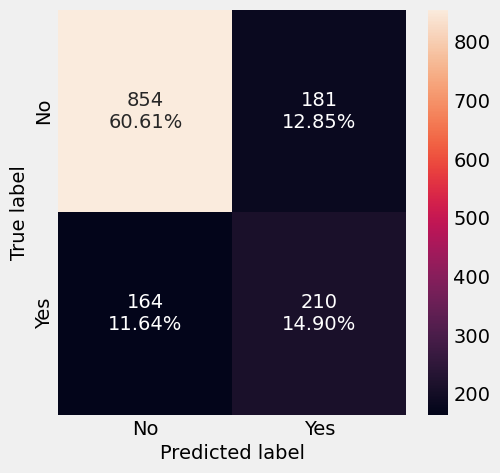

```python
cm = confusion_matrix(y_test, y_pred_test, labels = [0, 1])
df_cm = pd.DataFrame(cm, index = [i for i in ["No", "Yes"]], columns = [i for i in ["No", "Yes"]])

group_counts = ["{0:0.0f}".format(value) for value in cm.flatten()]
group_percentages = ["{0:.2%}".format(value) for value in cm.flatten()/np.sum(cm)]

labels = [f"{v1}\n{v2}" for v1, v2 in zip(group_counts, group_percentages)]
labels = np.asarray(labels).reshape(2, 2)

plt.figure(figsize = (5, 5))
sns.heatmap(df_cm, annot = labels, fmt = '')

plt.ylabel("True label")
plt.xlabel("Predicted label")
```

```python
# Tuned Model

print(metrics.classification_report(y_test, gradientBoostingClassifier_tuned.predict(X_test)))
```

```
              precision    recall  f1-score   support

           0       0.84      0.83      0.83      1035
           1       0.54      0.56      0.55       374

    accuracy                           0.76      1409
   macro avg       0.69      0.69      0.69      1409
weighted avg       0.76      0.76      0.76      1409
```

##### Thus, the Accuracy of the Tuned Gradient Boost Classifier model came out to be 76%

```python
# Un-Tuned Model

print(metrics.classification_report(y_test, gradientBoostingClassifier.predict(X_test)))
```

```
              precision    recall  f1-score   support

           0       0.83      0.92      0.88      1035
           1       0.69      0.49      0.58       374

    accuracy                           0.81      1409
   macro avg       0.76      0.71      0.73      1409
weighted avg       0.80      0.81      0.80      1409
```

##### Thus, the Accuracy of the Un-Tuned Gradient Boost Classifier model came out to be 81%

Insight :

- The model accuracy of Tuned gradientboost classification model has descreaed to 76% compared to Un-Tuned gradientboost classification model accuracy which is 81%

I. Provide detailed analysis of the below steps (4 marks ) :

(1) Compare the performance of each model in train stage and test stage

(2) Provide your observation on which model performed the best

(3) Provide your reasoning on why the model performed best

(4) Provide your final conclusion on your observation

```python
df_best_scores = pd.DataFrame({'Estimators': ['Decision Tree', 'Random Forest', 'Adaboost', 'GradientBoost'],
                               'Best Scores':['{0:.3f}'.format(model_DTC.best_score_), '{0:.3f}'.format(model_RFC.best_score_), '{0:.3f}'.format(model_ABC.best_score_), '{0:.3f}'.format(model_GBC.best_score_)]})

print(df_best_scores)
```

```
      Estimators Best Scores
0  Decision Tree       0.548
1  Random Forest       0.831
2       Adaboost       0.654
3  GradientBoost       0.585
```

##### Observations on best model performed below:

Based on the summary table, we can conclude that Random Forest Classifier (0.831) outperformed all the considered Estimators for the given dataset.

The Decision Tree Classifier and GradientBoost Classifier performed the worst among the four estimators (0.548 and 0.585).

##### Conclusions

In this article, we performed two comparisons.

- First, among each estimator, we compared the Accuracy before and after tuning the estimator.
- Second, we compared the GridSearchCV best scores of all the estimators. As mentioned earlier, these are results are specific to these problems only one cannot generalize the results for the problems. Thus, it would be incorrect to say that Random Forest is the best Classifier or Decision Tree Classifier is the worst.
- In another example, one may find Decision Tree Classifier performing better than other Classifiers. One can try experimenting with the results by changing the GridSearchCV() arguments or with a different dataset because one always learns by trying.